# Data Analysis Report on Police Misconduct

Bright Hoang | Paul Oh | Salma Yusuf

Autumn 2022

## Dynamic Paragraph

Police brutality is a major issue in the United States. Over the past decade, data on police misconduct and settlements have been recorded and collected by FiveThirtyEight and the Marshall Project, showcasing major cities within the United States that have been accumulating money put into these settlements caused by police misconduct cases. We found that in Chicago, police misconduct cases involving reversed conviction had the highest median settlements of $3,100,000. Police departments annually spent a significant amount of money on police misconduct settlements cases. In fact, in 2018, Los Angeles spent a total amount of $26,335,683 on police settlements, and the city of Chicago paid a median of $31,743,211 annually for police misconduct settlements. Furthermore, in New York City, the biggest settlement in a single case within the last 10 years was $26,875,657. Out of the 32,632 police misconduct cases in New York City, the majority of those cases, 21,467, to be precise, were categorized as “Peace Officer/Police Action.”

## Summary Table of Chicago Police Misconduct Cases and Settlements Throughout The Years in USD

|  | Year | Median Settlement per Case | Mean Settlement per Case | Highest Settlement Amount | Lowest Settlement Amount | Median Extended Detention / Malicious Prosecution Case | Mean Extended Detention / Malicious Prosecution Case | Median Excessive Force Minor Case | Mean Excessive Force Minor Case | Median Excessive Force Serious Case | Mean Excessive Force Serious Case | Median False Arrest Case | Mean False Arrest Case | Median Illegal Search/Seizure Case | Mean Illegal Search/Seizure Case | Median Reversed Conviction Case | Mean Reversed Conviction Case |
| --- | --- | --- | --- | --- | --- | --- | --- | --- | --- | --- | --- | --- | --- | --- | --- | --- | --- |
| 1 | 2010 | 25000 | 305778 | 16500000 | 1 | 80000 | 1878944 | 38000 | 44358 | 58374 | 153542 | 19750 | 57516 | 35000 | 35604 | 400000 | 400000 |
| 2 | 2011 | 30000 | 203483 | 6500000 | 1000 | 12000 | 117454 | 25000 | 67805 | 60000 | 374040 | 38000 | 136683 | 7300 | 43267 | 1250000 | 1250000 |
| 3 | 2012 | 40000 | 390242 | 26882946 | 1 | 32500 | 339897 | 16000 | 89980 | 62500 | 199673 | 50001 | 97621 | 10000 | 17956 | 3600000 | 7721589 |
| 4 | 2013 | 37500 | 506050 | 15000000 | 500 | 75000 | 386566 | 37297 | 64901 | 81500 | 805192 | 20000 | 58526 | 16250 | 27746 | 6262500 | 6787500 |
| 5 | 2014 | 30003 | 186598 | 7625000 | 1 | 435000 | 455222 | 24446 | 40600 | 100000 | 430821 | 30000 | 80241 | 27500 | 33718 | 640000 | 2916667 |
| 6 | 2015 | 30000 | 150062 | 5000000 | 350 | 60000 | 107400 | 16250 | 28660 | 92201 | 688753 | 30000 | 41260 | 25000 | 60599 | 80000 | 80000 |
| 7 | 2016 | 30000 | 160494 | 4950000 | 200 | 80000 | 273687 | 42000 | 54906 | 100000 | 661219 | 18500 | 27710 | 25000 | 53527 | 487500 | 487500 |
| 8 | 2017 | 37500 | 534597 | 44700000 | 1 | 60000 | 147030 | 30000 | 39899 | 133333 | 509883 | 30000 | 60883 | 30000 | 45956 | 4000000 | 4070714 |
| 9 | 2018 | 50000 | 314646 | 8080000 | 488 | 50000 | 62769 | 55000 | 108098 | 100000 | 516047 | 37000 | 52590 | 30000 | 83863 | 5250000 | 5520000 |
| 10 | 2019 | 50000 | 261709 | 5750000 | 1 | 100000 | 670636 | 22500 | 39762 | 100000 | 455738 | 50000 | 85157 | 46000 | 71630 | 275000 | 1463571 |

We included this table to show how differing types of misconduct cases *also* have differing settlement amounts, across all years from 2010 to 2019. The table has information about the **overall** mean and median, and also **individual** means and medians of certain *types* of cases, for each year.

### Chart 1:

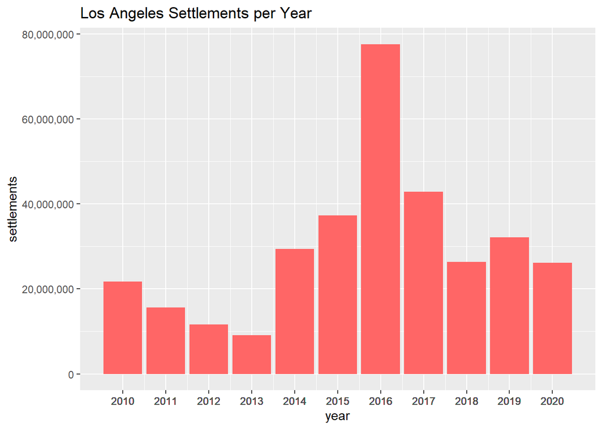

This is a column chart representing the amount of *settlement* money spent each *year*. The x-axis shows each year included in the data set, and the y-axis shows the total amount of settlements the city of Los Angeles spent each year. I chose to make this chart to show how much money was spent each year due to police misconduct. We can see that there is a significant amount that was spent in 2016 compared to the other years, and 2013 had the least amount of money spent.

### Chart 2:

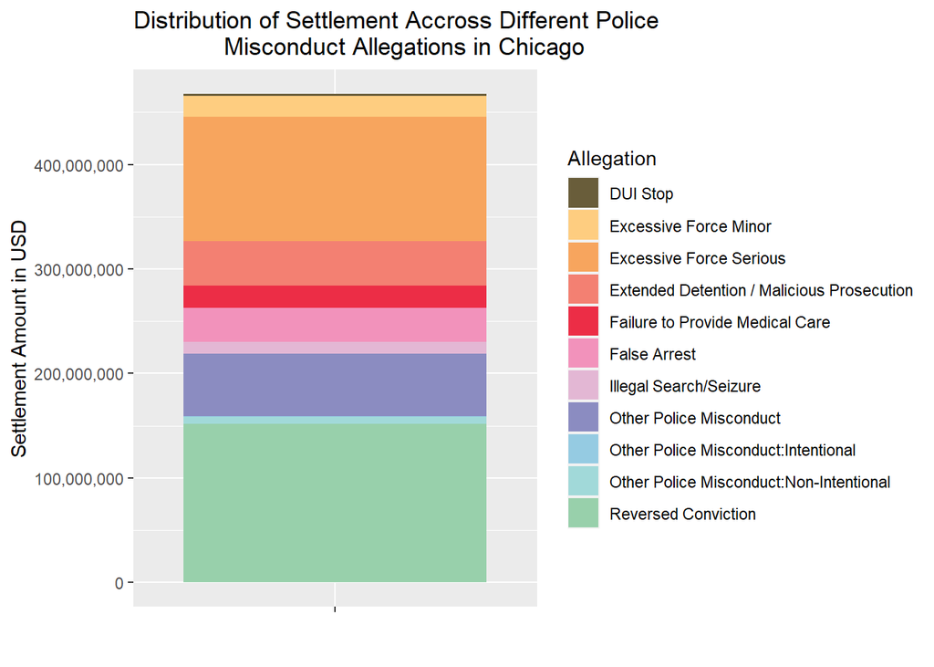

This is a stacked bar chart that visualizes the proportion of settlement money spent on different *types* of police misconduct in Chicago. This is important to observe because we can see which category of misconduct has the highest consequences and settlement amount. We can observe that **reversed conviction** and **serious excessive force** cases pay the highest amount of settlements.

### Chart 3:

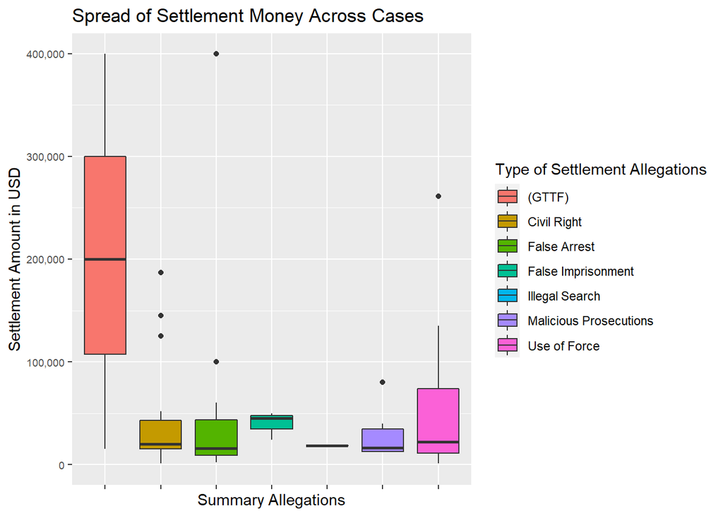

This is a box plot showing the **spread** of settlement money throughout different categories of cases within the city of Baltimore, Maryland. Within the summary_allegations axis are the different labels for the categories of cases, which go from Gun Trace Task Force officer misconducts, violations of civil rights, false arrests, false imprisonments, illegal searches, malicious prosecutions, and uses of force in order from left to right. The amount_awarded axis shows the settlement money used. Although there are two outliers within the violation of civil rights category, both of which exceed $600,000 and have been excluded from this box plot, this visualization shows that there is a much *greater spread of settlement money* going into the GTTF officer misconduct cases than the other cases. From this, we can figure out which cases produce a *greater issue* in police misconduct cases.